# Frequent Pattern Mining Algorithms - Apriori, FP Growth

```python
# Import Libraries
import pandas as pd
import numpy as np
import math
import itertools
import csv
import warnings
warnings.filterwarnings('ignore')


# Visualizations
import matplotlib.pyplot as plt
import seaborn as sns
from wordcloud import WordCloud
import networkx as nx

# Analysis
import mlxtend
from mlxtend.frequent_patterns import apriori, association_rules
```

```python
# Import further libraries if required
from mlxtend.frequent_patterns import apriori, association_rules,fpgrowth
from mlxtend.preprocessing import TransactionEncoder
from mlxtend.frequent_patterns import fpgrowth
```

```python
%pip install mlxtend --upgrade
```

# Task 1: Frequent Pattern Mining

## Load Dataset1:

Start by reading data from the CSV file. You are free to use any method to load the dataset from file.

```python
# Load data from Dataset1.csv
from google.colab import drive
drive.mount('/content/drive')
```

```python
data = pd.read_csv('/content/drive/MyDrive/Dataset1.csv')
data.shape
data.head()
```

|  | shrimp | almonds | avocado | vegetables mix | green grapes | whole weat flour | yams | cottage cheese | energy drink | tomato juice | low fat yogurt | green tea | honey | salad | mineral water | salmon | antioxydant juice | frozen smoothie | spinach | olive oil |
| --- | --- | --- | --- | --- | --- | --- | --- | --- | --- | --- | --- | --- | --- | --- | --- | --- | --- | --- | --- | --- |
| 0 | burgers | meatballs | eggs | NaN | NaN | NaN | NaN | NaN | NaN | NaN | NaN | NaN | NaN | NaN | NaN | NaN | NaN | NaN | NaN | NaN |
| 1 | chutney | NaN | NaN | NaN | NaN | NaN | NaN | NaN | NaN | NaN | NaN | NaN | NaN | NaN | NaN | NaN | NaN | NaN | NaN | NaN |
| 2 | turkey | avocado | NaN | NaN | NaN | NaN | NaN | NaN | NaN | NaN | NaN | NaN | NaN | NaN | NaN | NaN | NaN | NaN | NaN | NaN |
| 3 | mineral water | milk | energy bar | whole wheat rice | green tea | NaN | NaN | NaN | NaN | NaN | NaN | NaN | NaN | NaN | NaN | NaN | NaN | NaN | NaN | NaN |
| 4 | low fat yogurt | NaN | NaN | NaN | NaN | NaN | NaN | NaN | NaN | NaN | NaN | NaN | NaN | NaN | NaN | NaN | NaN | NaN | NaN | NaN |

## Exploratory Data Analysis:

```python
data.info()
```

```
<class 'pandas.core.frame.DataFrame'>
RangeIndex: 7500 entries, 0 to 7499
Data columns (total 20 columns):
 #   Column             Non-Null Count  Dtype
---  ------             --------------  -----
 0   shrimp             7500 non-null   object
 1   almonds            5746 non-null   object
 2   avocado            4388 non-null   object
 3   vegetables mix     3344 non-null   object
 4   green grapes       2528 non-null   object
 5   whole weat flour   1863 non-null   object
 6   yams               1368 non-null   object
 7   cottage cheese     980 non-null    object
 8   energy drink       653 non-null    object
 9   tomato juice       394 non-null    object
 10  low fat yogurt     255 non-null    object
 11  green tea          153 non-null    object
 12  honey              86 non-null     object
 13  salad              46 non-null     object
 14  mineral water      24 non-null     object
 15  salmon             7 non-null      object
 16  antioxydant juice  3 non-null      object
 17  frozen smoothie    3 non-null      object
 18  spinach            2 non-null      object
 19  olive oil          0 non-null      float64
dtypes: float64(1), object(19)
memory usage: 1.1+ MB
```

## Data Preprocessing:

```python
#data.fillna(0,inplace=True)
```

```python
transaction = []
for i in range(0,len(data)):
    transaction.append([str(data.values[i,j]) for j in range(0,20) if str(data.values[i,j])!='nan'])
transaction = np.array(transaction)
```

```python
te = TransactionEncoder()
te_ary = te.fit(transaction).transform(transaction)
dataset = pd.DataFrame(te_ary, columns=te.columns_)
dataset
```

|  | asparagus | almonds | antioxydant juice | asparagus | avocado | babies food | bacon | barbecue sauce | black tea | blueberries | ... | turkey | vegetables mix | water spray | white wine | whole weat flour | whole wheat pasta | whole wheat rice | yams | yogurt cake | zucchini |
| --- | --- | --- | --- | --- | --- | --- | --- | --- | --- | --- | --- | --- | --- | --- | --- | --- | --- | --- | --- | --- | --- |
| 0 | False | False | False | False | False | False | False | False | False | False | ... | False | False | False | False | False | False | False | False | False | False |
| 1 | False | False | False | False | False | False | False | False | False | False | ... | False | False | False | False | False | False | False | False | False | False |
| 2 | False | False | False | False | True | False | False | False | False | False | ... | True | False | False | False | False | False | False | False | False | False |
| 3 | False | False | False | False | False | False | False | False | False | False | ... | False | False | False | False | False | False | True | False | False | False |
| 4 | False | False | False | False | False | False | False | False | False | False | ... | False | False | False | False | False | False | False | False | False | False |
| ... | ... | ... | ... | ... | ... | ... | ... | ... | ... | ... | ... | ... | ... | ... | ... | ... | ... | ... | ... | ... | ... |
| 7495 | False | False | False | False | False | False | False | False | False | False | ... | False | False | False | False | False | False | False | False | False | False |
| 7496 | False | False | False | False | False | False | False | False | False | False | ... | False | False | False | False | False | False | False | False | False | False |
| 7497 | False | False | False | False | False | False | False | False | False | False | ... | False | False | False | False | False | False | False | False | False | False |
| 7498 | False | False | False | False | False | False | False | False | False | False | ... | False | False | False | False | False | False | False | False | False | False |
| 7499 | False | False | False | False | False | False | False | False | False | False | ... | False | False | False | False | False | False | False | False | True | False |

7500 rows × 120 columns

# Question: 1 Apriori algorithm [25 marks]

In this part, you are required to implement the **Apriori algorithm** for frequent itemsets mining.

### Identify Unique Items: [5 marks]

List the unique items in the dataset

```python
# Find and print all unique items in the dataset
print(dataset.columns)
```

```
Index([' asparagus', 'almonds', 'antioxydant juice', 'asparagus', 'avocado',
       'babies food', 'bacon', 'barbecue sauce', 'black tea', 'blueberries',
       ...
       'turkey', 'vegetables mix', 'water spray', 'white wine',
       'whole weat flour', 'whole wheat pasta', 'whole wheat rice', 'yams',
       'yogurt cake', 'zucchini'],
      dtype='object', length=120)
```

### Apriori Algorithm: [20 marks]

Print all freqent itemsets using minimum support count of 1%.

```python
frequent_itemsets = apriori(dataset, min_support=0.01, use_colnames=True)
frequent_itemsets
```

|  | support | itemsets |
| --- | --- | --- |
| 0 | 0.020267 | (almonds) |
| 1 | 0.033200 | (avocado) |
| 2 | 0.010800 | (barbecue sauce) |
| 3 | 0.014267 | (black tea) |
| 4 | 0.011467 | (body spray) |
| ... | ... | ... |
| 254 | 0.011067 | (milk, ground beef, mineral water) |
| 255 | 0.017067 | (ground beef, spaghetti, mineral water) |
| 256 | 0.015733 | (milk, spaghetti, mineral water) |
| 257 | 0.010267 | (olive oil, spaghetti, mineral water) |
| 258 | 0.011467 | (pancakes, spaghetti, mineral water) |

259 rows × 2 columns

```python
# association_rules() function help us to understand relationship between antecedents and consequences products
## min_threshold = 0.3
rules = association_rules(frequent_itemsets, metric="lift", min_threshold=0.3)
rules["antecedents_length"] = rules["antecedents"].apply(lambda x: len(x))
rules["consequents_length"] = rules["consequents"].apply(lambda x: len(x))
rules.sort_values("lift",ascending=False)
```

|  | antecedents | consequents | antecedent support | consequent support | support | confidence | lift | leverage | conviction | antecedents_length | consequents_length |
| --- | --- | --- | --- | --- | --- | --- | --- | --- | --- | --- | --- |
| 242 | (herb & pepper) | (ground beef) | 0.049467 | 0.098267 | 0.016000 | 0.323450 | 3.291555 | 0.011139 | 1.332841 | 1 | 1 |
| 243 | (ground beef) | (herb & pepper) | 0.098267 | 0.049467 | 0.016000 | 0.162822 | 3.291555 | 0.011139 | 1.135402 | 1 | 1 |
| 414 | (mineral water, spaghetti) | (ground beef) | 0.059733 | 0.098267 | 0.017067 | 0.285714 | 2.907540 | 0.011197 | 1.262427 | 2 | 1 |
| 415 | (ground beef) | (mineral water, spaghetti) | 0.098267 | 0.059733 | 0.017067 | 0.173677 | 2.907540 | 0.011197 | 1.137893 | 1 | 2 |
| 427 | (olive oil) | (mineral water, spaghetti) | 0.065733 | 0.059733 | 0.010267 | 0.156187 | 2.614731 | 0.006340 | 1.114306 | 1 | 2 |
| ... | ... | ... | ... | ... | ... | ... | ... | ... | ... | ... | ... |
| 63 | (cookies) | (chocolate) | 0.080400 | 0.163867 | 0.010400 | 0.129353 | 0.789381 | -0.002775 | 0.960359 | 1 | 1 |
| 120 | (escalope) | (eggs) | 0.079333 | 0.179733 | 0.011067 | 0.139496 | 0.776126 | -0.003192 | 0.953240 | 1 | 1 |
| 121 | (eggs) | (escalope) | 0.179733 | 0.079333 | 0.011067 | 0.061573 | 0.776126 | -0.003192 | 0.981074 | 1 | 1 |
| 106 | (cookies) | (eggs) | 0.080400 | 0.179733 | 0.010533 | 0.131012 | 0.728922 | -0.003917 | 0.943933 | 1 | 1 |
| 107 | (eggs) | (cookies) | 0.179733 | 0.080400 | 0.010533 | 0.058605 | 0.728922 | -0.003917 | 0.976849 | 1 | 1 |

436 rows × 11 columns

```python
# find confidence
rules.sort_values("confidence",ascending=False)
```

|  | antecedents | consequents | antecedent support | consequent support | support | confidence | lift | leverage | conviction | antecedents_length | consequents_length |
| --- | --- | --- | --- | --- | --- | --- | --- | --- | --- | --- | --- |
| 370 | (eggs, ground beef) | (mineral water) | 0.020000 | 0.238267 | 0.010133 | 0.506667 | 2.126469 | 0.005368 | 1.544054 | 2 | 1 |
| 406 | (milk, ground beef) | (mineral water) | 0.022000 | 0.238267 | 0.011067 | 0.503030 | 2.111207 | 0.005825 | 1.532756 | 2 | 1 |
| 346 | (chocolate, ground beef) | (mineral water) | 0.023067 | 0.238267 | 0.010933 | 0.473988 | 1.989319 | 0.005437 | 1.448130 | 2 | 1 |
| 394 | (milk, frozen vegetables) | (mineral water) | 0.023600 | 0.238267 | 0.011067 | 0.468927 | 1.968075 | 0.005444 | 1.434328 | 2 | 1 |
| 300 | (soup) | (mineral water) | 0.050533 | 0.238267 | 0.023067 | 0.456464 | 1.915771 | 0.011026 | 1.401441 | 1 | 1 |
| ... | ... | ... | ... | ... | ... | ... | ... | ... | ... | ... | ... |
| 295 | (mineral water) | (red wine) | 0.238267 | 0.028133 | 0.010933 | 0.045887 | 1.631053 | 0.004230 | 1.018607 | 1 | 1 |
| 429 | (mineral water) | (olive oil, spaghetti) | 0.238267 | 0.022933 | 0.010267 | 0.043089 | 1.878880 | 0.004802 | 1.021063 | 1 | 2 |
| 45 | (mineral water) | (cereals) | 0.238267 | 0.025733 | 0.010267 | 0.043089 | 1.674442 | 0.004135 | 1.018137 | 1 | 1 |
| 392 | (mineral water) | (spaghetti, french fries) | 0.238267 | 0.027600 | 0.010133 | 0.042529 | 1.540920 | 0.003557 | 1.015593 | 1 | 2 |
| 375 | (mineral water) | (eggs, ground beef) | 0.238267 | 0.020000 | 0.010133 | 0.042529 | 2.126469 | 0.005368 | 1.023530 | 1 | 2 |

436 rows × 11 columns

Print all freqent itemsets using minimum support count of 3%.

```python
frequent_itemsets = apriori(dataset, min_support=0.03, use_colnames=True)
frequent_itemsets
```

|  | support | itemsets |
| --- | --- | --- |
| 0 | 0.033200 | (avocado) |
| 1 | 0.033733 | (brownies) |
| 2 | 0.087200 | (burgers) |
| 3 | 0.030133 | (butter) |
| 4 | 0.081067 | (cake) |
| 5 | 0.046800 | (champagne) |
| 6 | 0.060000 | (chicken) |
| 7 | 0.163867 | (chocolate) |
| 8 | 0.080400 | (cookies) |
| 9 | 0.051067 | (cooking oil) |
| 10 | 0.031733 | (cottage cheese) |
| 11 | 0.179733 | (eggs) |
| 12 | 0.079333 | (escalope) |
| 13 | 0.170933 | (french fries) |
| 14 | 0.043067 | (fresh bread) |
| 15 | 0.063200 | (frozen smoothie) |
| 16 | 0.095333 | (frozen vegetables) |
| 17 | 0.052400 | (grated cheese) |
| 18 | 0.132000 | (green tea) |
| 19 | 0.098267 | (ground beef) |
| 20 | 0.049467 | (herb & pepper) |
| 21 | 0.047333 | (honey) |
| 22 | 0.032400 | (hot dogs) |
| 23 | 0.076400 | (low fat yogurt) |
| 24 | 0.129600 | (milk) |
| 25 | 0.238267 | (mineral water) |
| 26 | 0.065733 | (olive oil) |
| 27 | 0.095067 | (pancakes) |
| 28 | 0.042400 | (salmon) |
| 29 | 0.071333 | (shrimp) |
| 30 | 0.050533 | (soup) |
| 31 | 0.174133 | (spaghetti) |
| 32 | 0.030267 | (tomato juice) |
| 33 | 0.068400 | (tomatoes) |
| 34 | 0.062533 | (turkey) |
| 35 | 0.058533 | (whole wheat rice) |
| 36 | 0.033200 | (chocolate, eggs) |
| 37 | 0.034400 | (chocolate, french fries) |
| 38 | 0.032133 | (chocolate, milk) |
| 39 | 0.052667 | (chocolate, mineral water) |
| 40 | 0.039200 | (chocolate, spaghetti) |
| 41 | 0.036400 | (eggs, french fries) |
| 42 | 0.030800 | (milk, eggs) |
| 43 | 0.050933 | (eggs, mineral water) |
| 44 | 0.036533 | (eggs, spaghetti) |
| 45 | 0.033733 | (mineral water, french fries) |
| 46 | 0.035733 | (frozen vegetables, mineral water) |
| 47 | 0.030933 | (green tea, mineral water) |
| 48 | 0.040933 | (ground beef, mineral water) |
| 49 | 0.039200 | (ground beef, spaghetti) |
| 50 | 0.048000 | (milk, mineral water) |
| 51 | 0.035467 | (milk, spaghetti) |
| 52 | 0.033733 | (pancakes, mineral water) |
| 53 | 0.059733 | (spaghetti, mineral water) |

```python
# association_rules() function help us to understand relationship between antecedents and consequences products
## min_threshold = 0.25
rules = association_rules(frequent_itemsets, metric="lift", min_threshold=0.25)
rules["antecedents_length"] = rules["antecedents"].apply(lambda x: len(x))
rules["consequents_length"] = rules["consequents"].apply(lambda x: len(x))
rules.sort_values("lift",ascending=False)
```

|  | antecedents | consequents | antecedent support | consequent support | support | confidence | lift | leverage | conviction | antecedents_length | consequents_length |
| --- | --- | --- | --- | --- | --- | --- | --- | --- | --- | --- | --- |
| 27 | (spaghetti) | (ground beef) | 0.174133 | 0.098267 | 0.039200 | 0.225115 | 2.290857 | 0.022088 | 1.163699 | 1 | 1 |
| 26 | (ground beef) | (spaghetti) | 0.098267 | 0.174133 | 0.039200 | 0.398915 | 2.290857 | 0.022088 | 1.373959 | 1 | 1 |
| 25 | (mineral water) | (ground beef) | 0.238267 | 0.098267 | 0.040933 | 0.171796 | 1.748266 | 0.017520 | 1.088782 | 1 | 1 |
| 24 | (ground beef) | (mineral water) | 0.098267 | 0.238267 | 0.040933 | 0.416554 | 1.748266 | 0.017520 | 1.305576 | 1 | 1 |
| 20 | (frozen vegetables) | (mineral water) | 0.095333 | 0.238267 | 0.035733 | 0.374825 | 1.573133 | 0.013019 | 1.218433 | 1 | 1 |
| 21 | (mineral water) | (frozen vegetables) | 0.238267 | 0.095333 | 0.035733 | 0.149972 | 1.573133 | 0.013019 | 1.064279 | 1 | 1 |
| 30 | (milk) | (spaghetti) | 0.129600 | 0.174133 | 0.035467 | 0.273663 | 1.571569 | 0.012899 | 1.137029 | 1 | 1 |
| 31 | (spaghetti) | (milk) | 0.174133 | 0.129600 | 0.035467 | 0.203675 | 1.571569 | 0.012899 | 1.093022 | 1 | 1 |
| 29 | (mineral water) | (milk) | 0.238267 | 0.129600 | 0.048000 | 0.201455 | 1.554436 | 0.017121 | 1.089982 | 1 | 1 |
| 28 | (milk) | (mineral water) | 0.129600 | 0.238267 | 0.048000 | 0.370370 | 1.554436 | 0.017121 | 1.209812 | 1 | 1 |
| 4 | (chocolate) | (milk) | 0.163867 | 0.129600 | 0.032133 | 0.196094 | 1.513074 | 0.010896 | 1.082714 | 1 | 1 |
| 5 | (milk) | (chocolate) | 0.129600 | 0.163867 | 0.032133 | 0.247942 | 1.513074 | 0.010896 | 1.111794 | 1 | 1 |
| 32 | (pancakes) | (mineral water) | 0.095067 | 0.238267 | 0.033733 | 0.354839 | 1.489250 | 0.011082 | 1.180687 | 1 | 1 |
| 33 | (mineral water) | (pancakes) | 0.238267 | 0.095067 | 0.033733 | 0.141578 | 1.489250 | 0.011082 | 1.054182 | 1 | 1 |
| 34 | (spaghetti) | (mineral water) | 0.174133 | 0.238267 | 0.059733 | 0.343032 | 1.439698 | 0.018243 | 1.159468 | 1 | 1 |
| 35 | (mineral water) | (spaghetti) | 0.238267 | 0.174133 | 0.059733 | 0.250699 | 1.439698 | 0.018243 | 1.102184 | 1 | 1 |
| 9 | (spaghetti) | (chocolate) | 0.174133 | 0.163867 | 0.039200 | 0.225115 | 1.373768 | 0.010665 | 1.079042 | 1 | 1 |
| 8 | (chocolate) | (spaghetti) | 0.163867 | 0.174133 | 0.039200 | 0.239219 | 1.373768 | 0.010665 | 1.085551 | 1 | 1 |
| 7 | (mineral water) | (chocolate) | 0.238267 | 0.163867 | 0.052667 | 0.221041 | 1.348907 | 0.013623 | 1.073398 | 1 | 1 |
| 6 | (chocolate) | (mineral water) | 0.163867 | 0.238267 | 0.052667 | 0.321400 | 1.348907 | 0.013623 | 1.122506 | 1 | 1 |
| 12 | (milk) | (eggs) | 0.129600 | 0.179733 | 0.030800 | 0.237654 | 1.322261 | 0.007507 | 1.075977 | 1 | 1 |
| 13 | (eggs) | (milk) | 0.179733 | 0.129600 | 0.030800 | 0.171365 | 1.322261 | 0.007507 | 1.050402 | 1 | 1 |
| 2 | (chocolate) | (french fries) | 0.163867 | 0.170933 | 0.034400 | 0.209927 | 1.228121 | 0.006390 | 1.049354 | 1 | 1 |
| 3 | (french fries) | (chocolate) | 0.170933 | 0.163867 | 0.034400 | 0.201248 | 1.228121 | 0.006390 | 1.046800 | 1 | 1 |
| 14 | (eggs) | (mineral water) | 0.179733 | 0.238267 | 0.050933 | 0.283383 | 1.189351 | 0.008109 | 1.062957 | 1 | 1 |
| 15 | (mineral water) | (eggs) | 0.238267 | 0.179733 | 0.050933 | 0.213766 | 1.189351 | 0.008109 | 1.043286 | 1 | 1 |
| 10 | (eggs) | (french fries) | 0.179733 | 0.170933 | 0.036400 | 0.202522 | 1.184803 | 0.005678 | 1.039611 | 1 | 1 |
| 11 | (french fries) | (eggs) | 0.170933 | 0.179733 | 0.036400 | 0.212949 | 1.184803 | 0.005678 | 1.042202 | 1 | 1 |
| 16 | (eggs) | (spaghetti) | 0.179733 | 0.174133 | 0.036533 | 0.203264 | 1.167290 | 0.005236 | 1.036563 | 1 | 1 |
| 17 | (spaghetti) | (eggs) | 0.174133 | 0.179733 | 0.036533 | 0.209801 | 1.167290 | 0.005236 | 1.038051 | 1 | 1 |
| 0 | (chocolate) | (eggs) | 0.163867 | 0.179733 | 0.033200 | 0.202604 | 1.127246 | 0.003748 | 1.028681 | 1 | 1 |
| 1 | (eggs) | (chocolate) | 0.179733 | 0.163867 | 0.033200 | 0.184718 | 1.127246 | 0.003748 | 1.025576 | 1 | 1 |
| 23 | (mineral water) | (green tea) | 0.238267 | 0.132000 | 0.030933 | 0.129827 | 0.983534 | -0.000518 | 0.997502 | 1 | 1 |
| 22 | (green tea) | (mineral water) | 0.132000 | 0.238267 | 0.030933 | 0.234343 | 0.983534 | -0.000518 | 0.994876 | 1 | 1 |
| 19 | (french fries) | (mineral water) | 0.170933 | 0.238267 | 0.033733 | 0.197348 | 0.828265 | -0.006994 | 0.949021 | 1 | 1 |
| 18 | (mineral water) | (french fries) | 0.238267 | 0.170933 | 0.033733 | 0.141578 | 0.828265 | -0.006994 | 0.965803 | 1 | 1 |

```python
# find confidence
rules.sort_values("confidence",ascending=False)
```

|  | antecedents | consequents | antecedent support | consequent support | support | confidence | lift | leverage | conviction | antecedents_length | consequents_length |
| --- | --- | --- | --- | --- | --- | --- | --- | --- | --- | --- | --- |
| 24 | (ground beef) | (mineral water) | 0.098267 | 0.238267 | 0.040933 | 0.416554 | 1.748266 | 0.017520 | 1.305576 | 1 | 1 |
| 26 | (ground beef) | (spaghetti) | 0.098267 | 0.174133 | 0.039200 | 0.398915 | 2.290857 | 0.022088 | 1.373959 | 1 | 1 |
| 20 | (frozen vegetables) | (mineral water) | 0.095333 | 0.238267 | 0.035733 | 0.374825 | 1.573133 | 0.013019 | 1.218433 | 1 | 1 |
| 28 | (milk) | (mineral water) | 0.129600 | 0.238267 | 0.048000 | 0.370370 | 1.554436 | 0.017121 | 1.209812 | 1 | 1 |
| 32 | (pancakes) | (mineral water) | 0.095067 | 0.238267 | 0.033733 | 0.354839 | 1.489250 | 0.011082 | 1.180687 | 1 | 1 |
| 34 | (spaghetti) | (mineral water) | 0.174133 | 0.238267 | 0.059733 | 0.343032 | 1.439698 | 0.018243 | 1.159468 | 1 | 1 |
| 6 | (chocolate) | (mineral water) | 0.163867 | 0.238267 | 0.052667 | 0.321400 | 1.348907 | 0.013623 | 1.122506 | 1 | 1 |
| 14 | (eggs) | (mineral water) | 0.179733 | 0.238267 | 0.050933 | 0.283383 | 1.189351 | 0.008109 | 1.062957 | 1 | 1 |
| 30 | (milk) | (spaghetti) | 0.129600 | 0.174133 | 0.035467 | 0.273663 | 1.571569 | 0.012899 | 1.137029 | 1 | 1 |
| 35 | (mineral water) | (spaghetti) | 0.238267 | 0.174133 | 0.059733 | 0.250699 | 1.439698 | 0.018243 | 1.102184 | 1 | 1 |
| 5 | (milk) | (chocolate) | 0.129600 | 0.163867 | 0.032133 | 0.247942 | 1.513074 | 0.010896 | 1.111794 | 1 | 1 |
| 8 | (chocolate) | (spaghetti) | 0.163867 | 0.174133 | 0.039200 | 0.239219 | 1.373768 | 0.010665 | 1.085551 | 1 | 1 |
| 12 | (milk) | (eggs) | 0.129600 | 0.179733 | 0.030800 | 0.237654 | 1.322261 | 0.007507 | 1.075977 | 1 | 1 |
| 22 | (green tea) | (mineral water) | 0.132000 | 0.238267 | 0.030933 | 0.234343 | 0.983534 | -0.000518 | 0.994876 | 1 | 1 |
| 9 | (spaghetti) | (chocolate) | 0.174133 | 0.163867 | 0.039200 | 0.225115 | 1.373768 | 0.010665 | 1.079042 | 1 | 1 |
| 27 | (spaghetti) | (ground beef) | 0.174133 | 0.098267 | 0.039200 | 0.225115 | 2.290857 | 0.022088 | 1.163699 | 1 | 1 |
| 7 | (mineral water) | (chocolate) | 0.238267 | 0.163867 | 0.052667 | 0.221041 | 1.348907 | 0.013623 | 1.073398 | 1 | 1 |
| 15 | (mineral water) | (eggs) | 0.238267 | 0.179733 | 0.050933 | 0.213766 | 1.189351 | 0.008109 | 1.043286 | 1 | 1 |
| 11 | (french fries) | (eggs) | 0.170933 | 0.179733 | 0.036400 | 0.212949 | 1.184803 | 0.005678 | 1.042202 | 1 | 1 |
| 2 | (chocolate) | (french fries) | 0.163867 | 0.170933 | 0.034400 | 0.209927 | 1.228121 | 0.006390 | 1.049354 | 1 | 1 |
| 17 | (spaghetti) | (eggs) | 0.174133 | 0.179733 | 0.036533 | 0.209801 | 1.167290 | 0.005236 | 1.038051 | 1 | 1 |
| 31 | (spaghetti) | (milk) | 0.174133 | 0.129600 | 0.035467 | 0.203675 | 1.571569 | 0.012899 | 1.093022 | 1 | 1 |
| 16 | (eggs) | (spaghetti) | 0.179733 | 0.174133 | 0.036533 | 0.203264 | 1.167290 | 0.005236 | 1.036563 | 1 | 1 |
| 0 | (chocolate) | (eggs) | 0.163867 | 0.179733 | 0.033200 | 0.202604 | 1.127246 | 0.003748 | 1.028681 | 1 | 1 |
| 10 | (eggs) | (french fries) | 0.179733 | 0.170933 | 0.036400 | 0.202522 | 1.184803 | 0.005678 | 1.039611 | 1 | 1 |
| 29 | (mineral water) | (milk) | 0.238267 | 0.129600 | 0.048000 | 0.201455 | 1.554436 | 0.017121 | 1.089982 | 1 | 1 |
| 3 | (french fries) | (chocolate) | 0.170933 | 0.163867 | 0.034400 | 0.201248 | 1.228121 | 0.006390 | 1.046800 | 1 | 1 |
| 19 | (french fries) | (mineral water) | 0.170933 | 0.238267 | 0.033733 | 0.197348 | 0.828265 | -0.006994 | 0.949021 | 1 | 1 |
| 4 | (chocolate) | (milk) | 0.163867 | 0.129600 | 0.032133 | 0.196094 | 1.513074 | 0.010896 | 1.082714 | 1 | 1 |
| 1 | (eggs) | (chocolate) | 0.179733 | 0.163867 | 0.033200 | 0.184718 | 1.127246 | 0.003748 | 1.025576 | 1 | 1 |
| 25 | (mineral water) | (ground beef) | 0.238267 | 0.098267 | 0.040933 | 0.171796 | 1.748266 | 0.017520 | 1.088782 | 1 | 1 |
| 13 | (eggs) | (milk) | 0.179733 | 0.129600 | 0.030800 | 0.171365 | 1.322261 | 0.007507 | 1.050402 | 1 | 1 |
| 21 | (mineral water) | (frozen vegetables) | 0.238267 | 0.095333 | 0.035733 | 0.149972 | 1.573133 | 0.013019 | 1.064279 | 1 | 1 |
| 33 | (mineral water) | (pancakes) | 0.238267 | 0.095067 | 0.033733 | 0.141578 | 1.489250 | 0.011082 | 1.054182 | 1 | 1 |
| 18 | (mineral water) | (french fries) | 0.238267 | 0.170933 | 0.033733 | 0.141578 | 0.828265 | -0.006994 | 0.965803 | 1 | 1 |
| 23 | (mineral water) | (green tea) | 0.238267 | 0.132000 | 0.030933 | 0.129827 | 0.983534 | -0.000518 | 0.997502 | 1 | 1 |

Print all freqent itemsets using minimum support count of 5%.

```python
frequent_itemsets = apriori(dataset, min_support=0.05, use_colnames=True)
frequent_itemsets
```

|  | support | itemsets |
| --- | --- | --- |
| 0 | 0.087200 | (burgers) |
| 1 | 0.081067 | (cake) |
| 2 | 0.060000 | (chicken) |
| 3 | 0.163867 | (chocolate) |
| 4 | 0.080400 | (cookies) |
| 5 | 0.051067 | (cooking oil) |
| 6 | 0.179733 | (eggs) |
| 7 | 0.079333 | (escalope) |
| 8 | 0.170933 | (french fries) |
| 9 | 0.063200 | (frozen smoothie) |
| 10 | 0.095333 | (frozen vegetables) |
| 11 | 0.052400 | (grated cheese) |
| 12 | 0.132000 | (green tea) |
| 13 | 0.098267 | (ground beef) |
| 14 | 0.076400 | (low fat yogurt) |
| 15 | 0.129600 | (milk) |
| 16 | 0.238267 | (mineral water) |
| 17 | 0.065733 | (olive oil) |
| 18 | 0.095067 | (pancakes) |
| 19 | 0.071333 | (shrimp) |
| 20 | 0.050533 | (soup) |
| 21 | 0.174133 | (spaghetti) |
| 22 | 0.068400 | (tomatoes) |
| 23 | 0.062533 | (turkey) |
| 24 | 0.058533 | (whole wheat rice) |
| 25 | 0.052667 | (chocolate, mineral water) |
| 26 | 0.050933 | (eggs, mineral water) |
| 27 | 0.059733 | (spaghetti, mineral water) |

```python
# association_rules() function help us to understand relationship between antecedents and consequences products
## min_threshold = 0.2
rules = association_rules(frequent_itemsets, metric="lift", min_threshold=0.2)
rules["antecedents_length"] = rules["antecedents"].apply(lambda x: len(x))
rules["consequents_length"] = rules["consequents"].apply(lambda x: len(x))
rules.sort_values("lift",ascending=False)
```

|  | antecedents | consequents | antecedent support | consequent support | support | confidence | lift | leverage | conviction | antecedents_length | consequents_length |
| --- | --- | --- | --- | --- | --- | --- | --- | --- | --- | --- | --- |
| 4 | (spaghetti) | (mineral water) | 0.174133 | 0.238267 | 0.059733 | 0.343032 | 1.439698 | 0.018243 | 1.159468 | 1 | 1 |
| 5 | (mineral water) | (spaghetti) | 0.238267 | 0.174133 | 0.059733 | 0.250699 | 1.439698 | 0.018243 | 1.102184 | 1 | 1 |
| 0 | (chocolate) | (mineral water) | 0.163867 | 0.238267 | 0.052667 | 0.321400 | 1.348907 | 0.013623 | 1.122506 | 1 | 1 |
| 1 | (mineral water) | (chocolate) | 0.238267 | 0.163867 | 0.052667 | 0.221041 | 1.348907 | 0.013623 | 1.073398 | 1 | 1 |
| 2 | (eggs) | (mineral water) | 0.179733 | 0.238267 | 0.050933 | 0.283383 | 1.189351 | 0.008109 | 1.062957 | 1 | 1 |
| 3 | (mineral water) | (eggs) | 0.238267 | 0.179733 | 0.050933 | 0.213766 | 1.189351 | 0.008109 | 1.043286 | 1 | 1 |

```python
# find confidence
rules.sort_values("confidence",ascending=False)
```

|  | antecedents | consequents | antecedent support | consequent support | support | confidence | lift | leverage | conviction | antecedents_length | consequents_length |
| --- | --- | --- | --- | --- | --- | --- | --- | --- | --- | --- | --- |
| 4 | (spaghetti) | (mineral water) | 0.174133 | 0.238267 | 0.059733 | 0.343032 | 1.439698 | 0.018243 | 1.159468 | 1 | 1 |
| 0 | (chocolate) | (mineral water) | 0.163867 | 0.238267 | 0.052667 | 0.321400 | 1.348907 | 0.013623 | 1.122506 | 1 | 1 |
| 2 | (eggs) | (mineral water) | 0.179733 | 0.238267 | 0.050933 | 0.283383 | 1.189351 | 0.008109 | 1.062957 | 1 | 1 |
| 5 | (mineral water) | (spaghetti) | 0.238267 | 0.174133 | 0.059733 | 0.250699 | 1.439698 | 0.018243 | 1.102184 | 1 | 1 |
| 1 | (mineral water) | (chocolate) | 0.238267 | 0.163867 | 0.052667 | 0.221041 | 1.348907 | 0.013623 | 1.073398 | 1 | 1 |
| 3 | (mineral water) | (eggs) | 0.238267 | 0.179733 | 0.050933 | 0.213766 | 1.189351 | 0.008109 | 1.043286 | 1 | 1 |

# Question: 2 FP Growth [20 marks]

In this part, you are required to implement the **FP Growth** for frequent itemsets mining.

Print all freqent itemsets using minimum support count of 1%.

```python
res=fpgrowth(dataset,min_support=0.01, use_colnames=True)
res
```

|  | support | itemsets |
| --- | --- | --- |
| 0 | 0.179733 | (eggs) |
| 1 | 0.087200 | (burgers) |
| 2 | 0.020933 | (meatballs) |
| 3 | 0.062533 | (turkey) |
| 4 | 0.033200 | (avocado) |
| ... | ... | ... |
| 254 | 0.014133 | (olive oil, ground beef) |
| 255 | 0.011333 | (frozen vegetables, olive oil) |
| 256 | 0.012000 | (olive oil, eggs) |
| 257 | 0.010800 | (pancakes, olive oil) |
| 258 | 0.010267 | (olive oil, spaghetti, mineral water) |

259 rows × 2 columns

```python
# association_rules() function help us to understand relationship between antecedents and consequences products
## min_threshold = 0.3

res=association_rules(res, metric="lift", min_threshold=0.3)
res
```

|  | antecedents | consequents | antecedent support | consequent support | support | confidence | lift | leverage | conviction |
| --- | --- | --- | --- | --- | --- | --- | --- | --- | --- |
| 0 | (eggs) | (mineral water) | 0.179733 | 0.238267 | 0.050933 | 0.283383 | 1.189351 | 0.008109 | 1.062957 |
| 1 | (mineral water) | (eggs) | 0.238267 | 0.179733 | 0.050933 | 0.213766 | 1.189351 | 0.008109 | 1.043286 |
| 2 | (eggs) | (burgers) | 0.179733 | 0.087200 | 0.028800 | 0.160237 | 1.837585 | 0.013127 | 1.086974 |
| 3 | (burgers) | (eggs) | 0.087200 | 0.179733 | 0.028800 | 0.330275 | 1.837585 | 0.013127 | 1.224782 |
| 4 | (mineral water) | (burgers) | 0.238267 | 0.087200 | 0.024400 | 0.102406 | 1.174384 | 0.003623 | 1.016941 |
| ... | ... | ... | ... | ... | ... | ... | ... | ... | ... |
| 431 | (olive oil, mineral water) | (spaghetti) | 0.027467 | 0.174133 | 0.010267 | 0.373786 | 2.146553 | 0.005484 | 1.318826 |
| 432 | (mineral water, spaghetti) | (olive oil) | 0.059733 | 0.065733 | 0.010267 | 0.171875 | 2.614731 | 0.006340 | 1.128171 |
| 433 | (olive oil) | (mineral water, spaghetti) | 0.065733 | 0.059733 | 0.010267 | 0.156187 | 2.614731 | 0.006340 | 1.114306 |
| 434 | (spaghetti) | (olive oil, mineral water) | 0.174133 | 0.027467 | 0.010267 | 0.058959 | 2.146553 | 0.005484 | 1.033465 |
| 435 | (mineral water) | (olive oil, spaghetti) | 0.238267 | 0.022933 | 0.010267 | 0.043089 | 1.878880 | 0.004802 | 1.021063 |

436 rows × 9 columns

```python
# find confidence
res.sort_values("confidence",ascending=False)
```

|  | antecedents | consequents | antecedent support | consequent support | support | confidence | lift | leverage | conviction |
| --- | --- | --- | --- | --- | --- | --- | --- | --- | --- |
| 352 | (eggs, ground beef) | (mineral water) | 0.020000 | 0.238267 | 0.010133 | 0.506667 | 2.126469 | 0.005368 | 1.544054 |
| 340 | (milk, ground beef) | (mineral water) | 0.022000 | 0.238267 | 0.011067 | 0.503030 | 2.111207 | 0.005825 | 1.532756 |
| 346 | (chocolate, ground beef) | (mineral water) | 0.023067 | 0.238267 | 0.010933 | 0.473988 | 1.989319 | 0.005437 | 1.448130 |
| 164 | (milk, frozen vegetables) | (mineral water) | 0.023600 | 0.238267 | 0.011067 | 0.468927 | 1.968075 | 0.005444 | 1.434328 |
| 128 | (soup) | (mineral water) | 0.050533 | 0.238267 | 0.023067 | 0.456464 | 1.915771 | 0.011026 | 1.401441 |
| ... | ... | ... | ... | ... | ... | ... | ... | ... | ... |
| 281 | (mineral water) | (red wine) | 0.238267 | 0.028133 | 0.010933 | 0.045887 | 1.631053 | 0.004230 | 1.018607 |
| 413 | (mineral water) | (cereals) | 0.238267 | 0.025733 | 0.010267 | 0.043089 | 1.674442 | 0.004135 | 1.018137 |
| 435 | (mineral water) | (olive oil, spaghetti) | 0.238267 | 0.022933 | 0.010267 | 0.043089 | 1.878880 | 0.004802 | 1.021063 |
| 122 | (mineral water) | (spaghetti, french fries) | 0.238267 | 0.027600 | 0.010133 | 0.042529 | 1.540920 | 0.003557 | 1.015593 |
| 357 | (mineral water) | (eggs, ground beef) | 0.238267 | 0.020000 | 0.010133 | 0.042529 | 2.126469 | 0.005368 | 1.023530 |

436 rows × 9 columns

Print all freqent itemsets using minimum support count of 3%.

```python
#  minimum support = 3%
res=fpgrowth(dataset,min_support=0.03, use_colnames=True)
res
```

|  | support | itemsets |
| --- | --- | --- |
| 0 | 0.179733 | (eggs) |
| 1 | 0.087200 | (burgers) |
| 2 | 0.062533 | (turkey) |
| 3 | 0.033200 | (avocado) |
| 4 | 0.238267 | (mineral water) |
| 5 | 0.132000 | (green tea) |
| 6 | 0.129600 | (milk) |
| 7 | 0.058533 | (whole wheat rice) |
| 8 | 0.076400 | (low fat yogurt) |
| 9 | 0.170933 | (french fries) |
| 10 | 0.050533 | (soup) |
| 11 | 0.174133 | (spaghetti) |
| 12 | 0.095333 | (frozen vegetables) |
| 13 | 0.080400 | (cookies) |
| 14 | 0.051067 | (cooking oil) |
| 15 | 0.046800 | (champagne) |
| 16 | 0.042400 | (salmon) |
| 17 | 0.163867 | (chocolate) |
| 18 | 0.071333 | (shrimp) |
| 19 | 0.060000 | (chicken) |
| 20 | 0.047333 | (honey) |
| 21 | 0.068400 | (tomatoes) |
| 22 | 0.095067 | (pancakes) |
| 23 | 0.052400 | (grated cheese) |
| 24 | 0.043067 | (fresh bread) |
| 25 | 0.098267 | (ground beef) |
| 26 | 0.079333 | (escalope) |
| 27 | 0.063200 | (frozen smoothie) |
| 28 | 0.049467 | (herb & pepper) |
| 29 | 0.081067 | (cake) |
| 30 | 0.031733 | (cottage cheese) |
| 31 | 0.032400 | (hot dogs) |
| 32 | 0.033733 | (brownies) |
| 33 | 0.065733 | (olive oil) |
| 34 | 0.030133 | (butter) |
| 35 | 0.030267 | (tomato juice) |
| 36 | 0.050933 | (eggs, mineral water) |
| 37 | 0.030933 | (green tea, mineral water) |
| 38 | 0.048000 | (milk, mineral water) |
| 39 | 0.035467 | (milk, spaghetti) |
| 40 | 0.032133 | (chocolate, milk) |
| 41 | 0.030800 | (milk, eggs) |
| 42 | 0.036400 | (eggs, french fries) |
| 43 | 0.033733 | (mineral water, french fries) |
| 44 | 0.059733 | (spaghetti, mineral water) |
| 45 | 0.036533 | (eggs, spaghetti) |
| 46 | 0.035733 | (frozen vegetables, mineral water) |
| 47 | 0.033200 | (chocolate, eggs) |
| 48 | 0.052667 | (chocolate, mineral water) |
| 49 | 0.034400 | (chocolate, french fries) |
| 50 | 0.039200 | (chocolate, spaghetti) |
| 51 | 0.033733 | (pancakes, mineral water) |
| 52 | 0.040933 | (ground beef, mineral water) |
| 53 | 0.039200 | (ground beef, spaghetti) |

```python
# association_rules() function help us to understand relationship between antecedents and consequences products
## min_threshold = 0.25

res=association_rules(res, metric="lift", min_threshold=0.25)
res
```

|  | antecedents | consequents | antecedent support | consequent support | support | confidence | lift | leverage | conviction |
| --- | --- | --- | --- | --- | --- | --- | --- | --- | --- |
| 0 | (eggs) | (mineral water) | 0.179733 | 0.238267 | 0.050933 | 0.283383 | 1.189351 | 0.008109 | 1.062957 |
| 1 | (mineral water) | (eggs) | 0.238267 | 0.179733 | 0.050933 | 0.213766 | 1.189351 | 0.008109 | 1.043286 |
| 2 | (green tea) | (mineral water) | 0.132000 | 0.238267 | 0.030933 | 0.234343 | 0.983534 | -0.000518 | 0.994876 |
| 3 | (mineral water) | (green tea) | 0.238267 | 0.132000 | 0.030933 | 0.129827 | 0.983534 | -0.000518 | 0.997502 |
| 4 | (milk) | (mineral water) | 0.129600 | 0.238267 | 0.048000 | 0.370370 | 1.554436 | 0.017121 | 1.209812 |
| 5 | (mineral water) | (milk) | 0.238267 | 0.129600 | 0.048000 | 0.201455 | 1.554436 | 0.017121 | 1.089982 |
| 6 | (milk) | (spaghetti) | 0.129600 | 0.174133 | 0.035467 | 0.273663 | 1.571569 | 0.012899 | 1.137029 |
| 7 | (spaghetti) | (milk) | 0.174133 | 0.129600 | 0.035467 | 0.203675 | 1.571569 | 0.012899 | 1.093022 |
| 8 | (chocolate) | (milk) | 0.163867 | 0.129600 | 0.032133 | 0.196094 | 1.513074 | 0.010896 | 1.082714 |
| 9 | (milk) | (chocolate) | 0.129600 | 0.163867 | 0.032133 | 0.247942 | 1.513074 | 0.010896 | 1.111794 |
| 10 | (milk) | (eggs) | 0.129600 | 0.179733 | 0.030800 | 0.237654 | 1.322261 | 0.007507 | 1.075977 |
| 11 | (eggs) | (milk) | 0.179733 | 0.129600 | 0.030800 | 0.171365 | 1.322261 | 0.007507 | 1.050402 |
| 12 | (eggs) | (french fries) | 0.179733 | 0.170933 | 0.036400 | 0.202522 | 1.184803 | 0.005678 | 1.039611 |
| 13 | (french fries) | (eggs) | 0.170933 | 0.179733 | 0.036400 | 0.212949 | 1.184803 | 0.005678 | 1.042202 |
| 14 | (mineral water) | (french fries) | 0.238267 | 0.170933 | 0.033733 | 0.141578 | 0.828265 | -0.006994 | 0.965803 |
| 15 | (french fries) | (mineral water) | 0.170933 | 0.238267 | 0.033733 | 0.197348 | 0.828265 | -0.006994 | 0.949021 |
| 16 | (spaghetti) | (mineral water) | 0.174133 | 0.238267 | 0.059733 | 0.343032 | 1.439698 | 0.018243 | 1.159468 |
| 17 | (mineral water) | (spaghetti) | 0.238267 | 0.174133 | 0.059733 | 0.250699 | 1.439698 | 0.018243 | 1.102184 |
| 18 | (eggs) | (spaghetti) | 0.179733 | 0.174133 | 0.036533 | 0.203264 | 1.167290 | 0.005236 | 1.036563 |
| 19 | (spaghetti) | (eggs) | 0.174133 | 0.179733 | 0.036533 | 0.209801 | 1.167290 | 0.005236 | 1.038051 |
| 20 | (frozen vegetables) | (mineral water) | 0.095333 | 0.238267 | 0.035733 | 0.374825 | 1.573133 | 0.013019 | 1.218433 |
| 21 | (mineral water) | (frozen vegetables) | 0.238267 | 0.095333 | 0.035733 | 0.149972 | 1.573133 | 0.013019 | 1.064279 |
| 22 | (chocolate) | (eggs) | 0.163867 | 0.179733 | 0.033200 | 0.202604 | 1.127246 | 0.003748 | 1.028681 |
| 23 | (eggs) | (chocolate) | 0.179733 | 0.163867 | 0.033200 | 0.184718 | 1.127246 | 0.003748 | 1.025576 |
| 24 | (chocolate) | (mineral water) | 0.163867 | 0.238267 | 0.052667 | 0.321400 | 1.348907 | 0.013623 | 1.122506 |
| 25 | (mineral water) | (chocolate) | 0.238267 | 0.163867 | 0.052667 | 0.221041 | 1.348907 | 0.013623 | 1.073398 |
| 26 | (chocolate) | (french fries) | 0.163867 | 0.170933 | 0.034400 | 0.209927 | 1.228121 | 0.006390 | 1.049354 |
| 27 | (french fries) | (chocolate) | 0.170933 | 0.163867 | 0.034400 | 0.201248 | 1.228121 | 0.006390 | 1.046800 |
| 28 | (chocolate) | (spaghetti) | 0.163867 | 0.174133 | 0.039200 | 0.239219 | 1.373768 | 0.010665 | 1.085551 |
| 29 | (spaghetti) | (chocolate) | 0.174133 | 0.163867 | 0.039200 | 0.225115 | 1.373768 | 0.010665 | 1.079042 |
| 30 | (pancakes) | (mineral water) | 0.095067 | 0.238267 | 0.033733 | 0.354839 | 1.489250 | 0.011082 | 1.180687 |
| 31 | (mineral water) | (pancakes) | 0.238267 | 0.095067 | 0.033733 | 0.141578 | 1.489250 | 0.011082 | 1.054182 |
| 32 | (ground beef) | (mineral water) | 0.098267 | 0.238267 | 0.040933 | 0.416554 | 1.748266 | 0.017520 | 1.305576 |
| 33 | (mineral water) | (ground beef) | 0.238267 | 0.098267 | 0.040933 | 0.171796 | 1.748266 | 0.017520 | 1.088782 |
| 34 | (ground beef) | (spaghetti) | 0.098267 | 0.174133 | 0.039200 | 0.398915 | 2.290857 | 0.022088 | 1.373959 |
| 35 | (spaghetti) | (ground beef) | 0.174133 | 0.098267 | 0.039200 | 0.225115 | 2.290857 | 0.022088 | 1.163699 |

```python
# find confidence
res.sort_values("confidence",ascending=False)
```

|  | antecedents | consequents | antecedent support | consequent support | support | confidence | lift | leverage | conviction |
| --- | --- | --- | --- | --- | --- | --- | --- | --- | --- |
| 32 | (ground beef) | (mineral water) | 0.098267 | 0.238267 | 0.040933 | 0.416554 | 1.748266 | 0.017520 | 1.305576 |
| 34 | (ground beef) | (spaghetti) | 0.098267 | 0.174133 | 0.039200 | 0.398915 | 2.290857 | 0.022088 | 1.373959 |
| 20 | (frozen vegetables) | (mineral water) | 0.095333 | 0.238267 | 0.035733 | 0.374825 | 1.573133 | 0.013019 | 1.218433 |
| 4 | (milk) | (mineral water) | 0.129600 | 0.238267 | 0.048000 | 0.370370 | 1.554436 | 0.017121 | 1.209812 |
| 30 | (pancakes) | (mineral water) | 0.095067 | 0.238267 | 0.033733 | 0.354839 | 1.489250 | 0.011082 | 1.180687 |
| 16 | (spaghetti) | (mineral water) | 0.174133 | 0.238267 | 0.059733 | 0.343032 | 1.439698 | 0.018243 | 1.159468 |
| 24 | (chocolate) | (mineral water) | 0.163867 | 0.238267 | 0.052667 | 0.321400 | 1.348907 | 0.013623 | 1.122506 |
| 0 | (eggs) | (mineral water) | 0.179733 | 0.238267 | 0.050933 | 0.283383 | 1.189351 | 0.008109 | 1.062957 |
| 6 | (milk) | (spaghetti) | 0.129600 | 0.174133 | 0.035467 | 0.273663 | 1.571569 | 0.012899 | 1.137029 |
| 17 | (mineral water) | (spaghetti) | 0.238267 | 0.174133 | 0.059733 | 0.250699 | 1.439698 | 0.018243 | 1.102184 |
| 9 | (milk) | (chocolate) | 0.129600 | 0.163867 | 0.032133 | 0.247942 | 1.513074 | 0.010896 | 1.111794 |
| 28 | (chocolate) | (spaghetti) | 0.163867 | 0.174133 | 0.039200 | 0.239219 | 1.373768 | 0.010665 | 1.085551 |
| 10 | (milk) | (eggs) | 0.129600 | 0.179733 | 0.030800 | 0.237654 | 1.322261 | 0.007507 | 1.075977 |
| 2 | (green tea) | (mineral water) | 0.132000 | 0.238267 | 0.030933 | 0.234343 | 0.983534 | -0.000518 | 0.994876 |
| 29 | (spaghetti) | (chocolate) | 0.174133 | 0.163867 | 0.039200 | 0.225115 | 1.373768 | 0.010665 | 1.079042 |
| 35 | (spaghetti) | (ground beef) | 0.174133 | 0.098267 | 0.039200 | 0.225115 | 2.290857 | 0.022088 | 1.163699 |
| 25 | (mineral water) | (chocolate) | 0.238267 | 0.163867 | 0.052667 | 0.221041 | 1.348907 | 0.013623 | 1.073398 |
| 1 | (mineral water) | (eggs) | 0.238267 | 0.179733 | 0.050933 | 0.213766 | 1.189351 | 0.008109 | 1.043286 |
| 13 | (french fries) | (eggs) | 0.170933 | 0.179733 | 0.036400 | 0.212949 | 1.184803 | 0.005678 | 1.042202 |
| 26 | (chocolate) | (french fries) | 0.163867 | 0.170933 | 0.034400 | 0.209927 | 1.228121 | 0.006390 | 1.049354 |
| 19 | (spaghetti) | (eggs) | 0.174133 | 0.179733 | 0.036533 | 0.209801 | 1.167290 | 0.005236 | 1.038051 |
| 7 | (spaghetti) | (milk) | 0.174133 | 0.129600 | 0.035467 | 0.203675 | 1.571569 | 0.012899 | 1.093022 |
| 18 | (eggs) | (spaghetti) | 0.179733 | 0.174133 | 0.036533 | 0.203264 | 1.167290 | 0.005236 | 1.036563 |
| 22 | (chocolate) | (eggs) | 0.163867 | 0.179733 | 0.033200 | 0.202604 | 1.127246 | 0.003748 | 1.028681 |
| 12 | (eggs) | (french fries) | 0.179733 | 0.170933 | 0.036400 | 0.202522 | 1.184803 | 0.005678 | 1.039611 |
| 5 | (mineral water) | (milk) | 0.238267 | 0.129600 | 0.048000 | 0.201455 | 1.554436 | 0.017121 | 1.089982 |
| 27 | (french fries) | (chocolate) | 0.170933 | 0.163867 | 0.034400 | 0.201248 | 1.228121 | 0.006390 | 1.046800 |
| 15 | (french fries) | (mineral water) | 0.170933 | 0.238267 | 0.033733 | 0.197348 | 0.828265 | -0.006994 | 0.949021 |
| 8 | (chocolate) | (milk) | 0.163867 | 0.129600 | 0.032133 | 0.196094 | 1.513074 | 0.010896 | 1.082714 |
| 23 | (eggs) | (chocolate) | 0.179733 | 0.163867 | 0.033200 | 0.184718 | 1.127246 | 0.003748 | 1.025576 |
| 33 | (mineral water) | (ground beef) | 0.238267 | 0.098267 | 0.040933 | 0.171796 | 1.748266 | 0.017520 | 1.088782 |
| 11 | (eggs) | (milk) | 0.179733 | 0.129600 | 0.030800 | 0.171365 | 1.322261 | 0.007507 | 1.050402 |
| 21 | (mineral water) | (frozen vegetables) | 0.238267 | 0.095333 | 0.035733 | 0.149972 | 1.573133 | 0.013019 | 1.064279 |
| 14 | (mineral water) | (french fries) | 0.238267 | 0.170933 | 0.033733 | 0.141578 | 0.828265 | -0.006994 | 0.965803 |
| 31 | (mineral water) | (pancakes) | 0.238267 | 0.095067 | 0.033733 | 0.141578 | 1.489250 | 0.011082 | 1.054182 |
| 3 | (mineral water) | (green tea) | 0.238267 | 0.132000 | 0.030933 | 0.129827 | 0.983534 | -0.000518 | 0.997502 |

Print all freqent itemsets using minimum support count of 5%.

```python
#  minimum support = 5%

res=fpgrowth(dataset,min_support=0.05, use_colnames=True)
res
```

|  | support | itemsets |
| --- | --- | --- |
| 0 | 0.179733 | (eggs) |
| 1 | 0.087200 | (burgers) |
| 2 | 0.062533 | (turkey) |
| 3 | 0.238267 | (mineral water) |
| 4 | 0.132000 | (green tea) |
| 5 | 0.129600 | (milk) |
| 6 | 0.058533 | (whole wheat rice) |
| 7 | 0.076400 | (low fat yogurt) |
| 8 | 0.170933 | (french fries) |
| 9 | 0.050533 | (soup) |
| 10 | 0.174133 | (spaghetti) |
| 11 | 0.095333 | (frozen vegetables) |
| 12 | 0.080400 | (cookies) |
| 13 | 0.051067 | (cooking oil) |
| 14 | 0.163867 | (chocolate) |
| 15 | 0.071333 | (shrimp) |
| 16 | 0.060000 | (chicken) |
| 17 | 0.068400 | (tomatoes) |
| 18 | 0.095067 | (pancakes) |
| 19 | 0.052400 | (grated cheese) |
| 20 | 0.098267 | (ground beef) |
| 21 | 0.079333 | (escalope) |
| 22 | 0.063200 | (frozen smoothie) |
| 23 | 0.081067 | (cake) |
| 24 | 0.065733 | (olive oil) |
| 25 | 0.050933 | (eggs, mineral water) |
| 26 | 0.059733 | (spaghetti, mineral water) |
| 27 | 0.052667 | (chocolate, mineral water) |

```python
# association_rules() function help us to understand relationship between antecedents and consequences products
## min_threshold = 0.2
# importing required module
res=association_rules(res, metric="lift", min_threshold=0.2)
res
```

|  | antecedents | consequents | antecedent support | consequent support | support | confidence | lift | leverage | conviction |
| --- | --- | --- | --- | --- | --- | --- | --- | --- | --- |
| 0 | (eggs) | (mineral water) | 0.179733 | 0.238267 | 0.050933 | 0.283383 | 1.189351 | 0.008109 | 1.062957 |
| 1 | (mineral water) | (eggs) | 0.238267 | 0.179733 | 0.050933 | 0.213766 | 1.189351 | 0.008109 | 1.043286 |
| 2 | (spaghetti) | (mineral water) | 0.174133 | 0.238267 | 0.059733 | 0.343032 | 1.439698 | 0.018243 | 1.159468 |
| 3 | (mineral water) | (spaghetti) | 0.238267 | 0.174133 | 0.059733 | 0.250699 | 1.439698 | 0.018243 | 1.102184 |
| 4 | (chocolate) | (mineral water) | 0.163867 | 0.238267 | 0.052667 | 0.321400 | 1.348907 | 0.013623 | 1.122506 |
| 5 | (mineral water) | (chocolate) | 0.238267 | 0.163867 | 0.052667 | 0.221041 | 1.348907 | 0.013623 | 1.073398 |

```python
# find confidence
res.sort_values("confidence",ascending=False)
```

|  | antecedents | consequents | antecedent support | consequent support | support | confidence | lift | leverage | conviction |
| --- | --- | --- | --- | --- | --- | --- | --- | --- | --- |
| 2 | (spaghetti) | (mineral water) | 0.174133 | 0.238267 | 0.059733 | 0.343032 | 1.439698 | 0.018243 | 1.159468 |
| 4 | (chocolate) | (mineral water) | 0.163867 | 0.238267 | 0.052667 | 0.321400 | 1.348907 | 0.013623 | 1.122506 |
| 0 | (eggs) | (mineral water) | 0.179733 | 0.238267 | 0.050933 | 0.283383 | 1.189351 | 0.008109 | 1.062957 |
| 3 | (mineral water) | (spaghetti) | 0.238267 | 0.174133 | 0.059733 | 0.250699 | 1.439698 | 0.018243 | 1.102184 |
| 5 | (mineral water) | (chocolate) | 0.238267 | 0.163867 | 0.052667 | 0.221041 | 1.348907 | 0.013623 | 1.073398 |
| 1 | (mineral water) | (eggs) | 0.238267 | 0.179733 | 0.050933 | 0.213766 | 1.189351 | 0.008109 | 1.043286 |

## Question: 3 Execution Time comparison of Apriori and FP Growth [20 marks]

```python
from timeit import repeat
import timeit
X = []
Y = []

apriorii = []
fpgrowthh = []
```

```python
testcases = ['''
def fn():
    return apriori(data, min_support = 0.01, use_colnames=True)
''',
'''
def fn():
    return fpgrowth(data, min_support = 0.01, use_colnames=True)
''']

apriorii.append(timeit.timeit(stmt=testcases[0]))
fpgrowthh.append(timeit.timeit(stmt=testcases[1]))
```

```python
testcases = ['''
def fn():
    return apriori(data, min_support = 0.03, use_colnames=True)
''',
'''
def fn():
    return fpgrowth(data, min_support = 0.03, use_colnames=True)
''']
apriorii.append(timeit.timeit(stmt=testcases[0]))
fpgrowthh.append(timeit.timeit(stmt=testcases[1]))
```

```python
testcases = ['''
def fn():
    return apriori(data, min_support = 0.05, use_colnames=True)
''',
'''
def fn():
    return fpgrowth(data, min_support = 0.05, use_colnames=True)
''']

apriorii.append(timeit.timeit(stmt=testcases[0]))
fpgrowthh.append(timeit.timeit(stmt=testcases[1]))
```

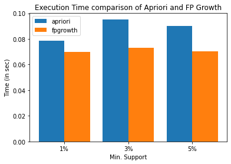

```python
## Overall Comparison "1%","3%","5%" for both Apriori and FP Growth
## Execution time comparison of Apriori and FP Growth



X = ['1%','3%','5%']


X_axis = np.arange(len(X))

plt.bar(X_axis - 0.2, apriorii, 0.4, label = 'apriori')
plt.bar(X_axis + 0.2, fpgrowthh, 0.4, label = 'fpgrowth')

plt.xticks(X_axis, X)
plt.xlabel("Min. Support")
plt.ylabel("Time (in sec)")
plt.title("Execution Time comparison of Apriori and FP Growth")
plt.legend()
plt.show()
```

## Evaluation Takeaways: [10 marks]

a) Based on your results above, is there any performance difference between the two algorithms? If so which one is faster? [1 mark]

b) What impact does changing the minimum support value has and why? [2 marks]

c) The dataset contains around 7,500 transactions. Why were very few frequent itemsets returned? [2 marks]

Ans: After data cleaning and eliminating elements below minimum support, the algorithm picks out only the frequent items

# Task 2: Frequent Pattern Mining

## Load Dataset2:

Start by reading data from the CSV file. You are free to use any method to load the dataset from file.

```python
# Load data from Dataset2.csv
pdDf = pd.read_csv('/content/drive/MyDrive/Dataset2.csv', error_bad_lines=False)

pdDf
```

[output not shown]

|  | Lassi | Coffee Powder | Butter | Yougurt | Ghee | Cheese | Unnamed: 6 |
| --- | --- | --- | --- | --- | --- | --- | --- |
| 0 | Ghee | Coffee Powder | NaN | NaN | NaN | NaN | NaN |
| 1 | Lassi | Tea Powder | Butter | Cheese | NaN | NaN | NaN |
| 2 | Cheese | Tea Powder | Panner | Coffee Powder | Butter | Bread | NaN |
| 3 | Cheese | Yougurt | Coffee Powder | Sugar | Butter | Sweet | NaN |
| 4 | Sugar | Tea Powder | Ghee | Sweet | Panner | Milk | NaN |
| ... | ... | ... | ... | ... | ... | ... | ... |
| 8726 | Panner | Sugar | Bread | Milk | Cheese | NaN | NaN |
| 8727 | Sugar | Bread | Coffee Powder | Cheese | NaN | NaN | NaN |
| 8728 | Bread | Cheese | Yougurt | Milk | NaN | NaN | NaN |
| 8729 | Ghee | Bread | Yougurt | Sugar | Cheese | NaN | NaN |
| 8730 | Panner | Yougurt | Bread | NaN | NaN | NaN | NaN |

8731 rows × 7 columns

```python
arr = pdDf.to_numpy()
arr[0]

transaction = []
for i in range(0,pdDf.shape[0]):
    transaction.append([str(pdDf.values[i,j]) for j in range(0,pdDf.shape[1]) if str(pdDf.values[i,j])!='nan'])
transaction = np.array(transaction)
```

```python
print(arr)
```

```
[['Ghee' 'Coffee Powder' nan ... nan nan nan]
 ['Lassi' 'Tea Powder' 'Butter' ... nan nan nan]
 ['Cheese' 'Tea Powder' 'Panner' ... 'Butter' 'Bread' nan]
 ...
 ['Bread' 'Cheese' 'Yougurt' ... nan nan nan]
 ['Ghee' 'Bread' 'Yougurt' ... 'Cheese' nan nan]
 ['Panner' 'Yougurt' 'Bread' ... nan nan nan]]
```

```python
print(transaction)
```

```
[list(['Ghee', 'Coffee Powder'])
 list(['Lassi', 'Tea Powder', 'Butter', 'Cheese'])
 list(['Cheese', 'Tea Powder', 'Panner', 'Coffee Powder', 'Butter', 'Bread'])
 ... list(['Bread', 'Cheese', 'Yougurt', 'Milk'])
 list(['Ghee', 'Bread', 'Yougurt', 'Sugar', 'Cheese'])
 list(['Panner', 'Yougurt', 'Bread'])]
```